# Introduction to version control with Git in RStudio

Sarah von Grebmer zu Wolfsthurn

Sarah.Grebmer@psy.lmu.de

LMU Open Science Center

Felix Schönbrodt

felix.schoenbrodt@psy.lmu.de

Ludwig-Maximilians-Universität München

2026-11-20

## Prerequisites

**Important**

Before completing this submodule, please carefully read about the prerequisites.

| Prerequisite | Description | Link/Where to find it |
| --- | --- | --- |
| Basic computer literacy | Making a folder; creating, saving or renaming files | - |
| Laptop/PC with internet access | Admin rights for download/install | - |
| R and RStudio installed | Latest versions of both R and RStudio | https://posit.co/download/rstudio-desktop/ |
| Basic R skills | 3.2 Introduction to R - Part I | LINK |
| Advanced R skills | 3.3 Introduction to R - Part II | LINK |
| GitHub account | Free account for GitHub | Join at https://github.com/join |

## Learning goals

- **Understand** the problem(s) that can be solved by version control
- **Install** and **configure** Git
- **Set up** the connection between your computer and GitHub
- **Create** an RStudio Project under version control for a reproducible workflow
- **Make** changes within RStudio and **commit** changes locally
- **Connect** local and remote repositories for your work

## Key terms and definitions

- **Reproducible workflows**:
- **RStudio Project**:
- **Git**:
- **GitHub**:
- **Repositories**:

## Key terms and definitions

- **Reproducible workflows**: Structured process ensuring that the methods can be consistently repeated by others using the same approach, data and tools
- **RStudio Project**: A way to store all files related to one R project in one place (R scripts, files, workspace, history, …) via a so-called .Rproj file
- **Git**: Version control system that tracks and manages changes to files and code
- **GitHub**: Cloud-based version control platform for hosting Git repositories which includes collaboration features
- **Repositories**: Git terminology for a folder where the contents of the folder are being tracked by Git

# Some realistic challenges in our (study and work)lives …

## Challenge 1: Document and project management

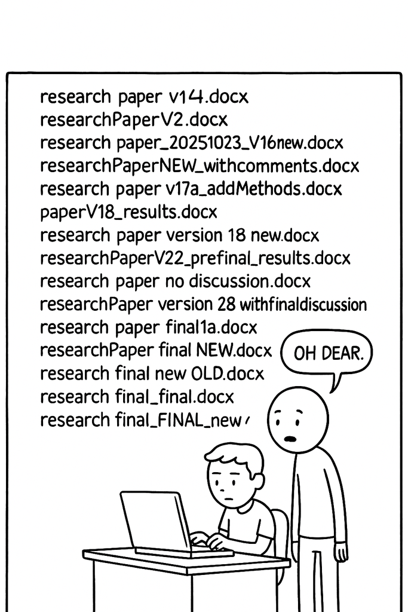

**Multiple versions** of the same project/document “floating” around on your PC.

**Sound familiar?**

What is your current **document naming and management** strategy?

## Challenge 2: When hardware fails

Laptop dies, files are accidentally deleted.

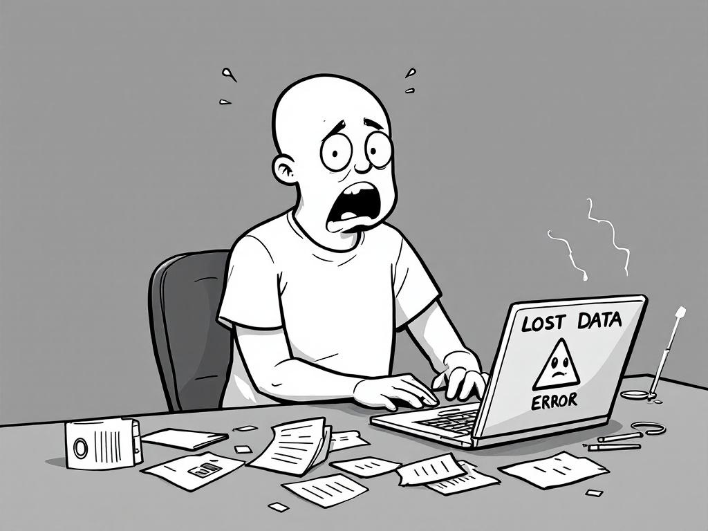

**Note**

Mentally raise your hand if this happened to you before.

## Challenge 3: “What on earth did I do again..?”

Projects evolve, it is easy to **forget** what we last changed or did on the project.

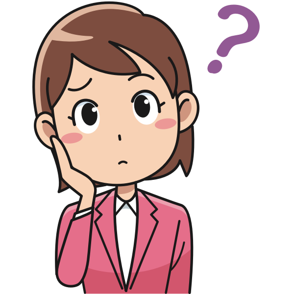

## Challenge 4: “But I just wanted to try to …”

Especially with coding, trying new ideas can **break** your code.

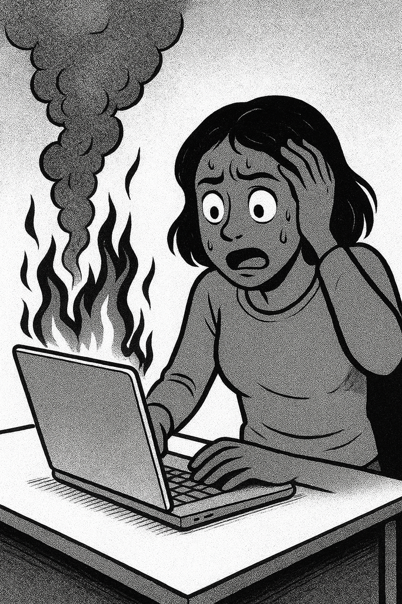

## Who is familiar with these problems?

1. Inconsistent data and file management aka **I cannot find my files**
2. Hardware failures (coffee spill, laptop dropped, lost laptop, broken USB) aka **my work is lost**
3. Extended periods of time between project actions aka **I forgot what I was working on**
4. Experimentation with new features aka **I tried something and my laptop is now smoking**
5. All of the above
6. None of the above (are you *sure*?)

# A realistic solution to these challenges?

## Version control

“Version … *what?*”

- **Version control** = system that **records changes** to files **over time** by recording the difference between two files
- **Tracks modifications** and edits
- Helps you **manage different versions**
- Allows you to **recover previous versions**

## Before we start: Survey time!

**What is your level of familiarity with version control?**

1. I have never heard of it before.
2. I have heard of it but have never worked with it.
3. I have a basic understanding and some experience with it.
4. I am very familiar and have worked with it extensively.

**Which of the following concepts or skills do you feel confident in? (Select all that apply.)**

1. Git
2. GitHub
3. Repositories
4. RStudio Project
5. I am not sure about any of these concepts.

**How comfortable are you with using Git for version control?**

1. 1 = Not comfortable at all
2. 2
3. 3
4. 4
5. 5 = Very comfortable

## Discussion of survey results

What do we see in the results?

## Git: What is it?

**Git** is a free and **open source software**. With Git, you can:

- **Track changes** to files across folders over time, seeing what was changed, when and by whom
- **Collaborate** efficiently within a team as multiple people can work on the same folders and files

[figure not shown]

## GitHub: What is it?

**GitHub** is a **cloud-based version control platform** that uses Git to track changes and hosts Git repositories.

- Allows multiple people to **collaborate** on the same project
- Collaborators can **share** repositories, code etc. and ask for **feedback**, initiate discussions and point out bugs and issues
- GitHub **stores** all files remotely, making it accessible from anywhere

[figure not shown]

**Note**

GitHub is a free but commercial platform owned by Microsoft. A similar functionality is provided by GitLab, Codeberg, and other providers; some of them open source and non-commercial.

## The Git - GitHub workflow

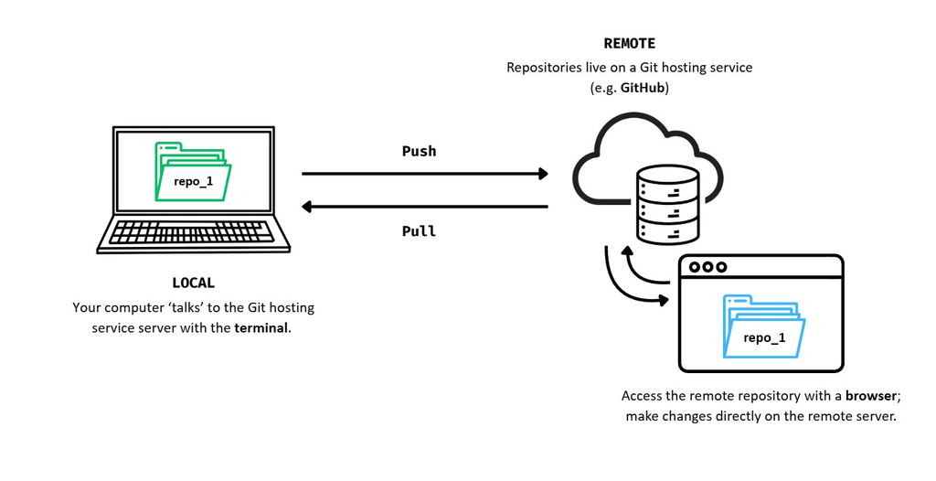

## #explainlikeIamfive

In pairs, explain the Git - GitHub workflow to your partner. What is the difference between **pushing** and **pulling**?

## What is a “Git Forge”?

- Git handles *version tracking* locally and across repositories.
- A git forge adds a web-based layer and *collaboration features* on top of Git, such as:
  - Access control (permissions, teams)
  - Pull/Merge requests (propose and review changes)
  - Issue tracking (bug reports, tasks)
  - Code review tools (comments, approvals)
  - CI/CD integration (automated testing and deployment)
  - Web interface (browse code, history, diffs)

**Note**

Git = the engine that tracks changes  
Git forge = the full collaboration platform built around that engine (GitHub, GitLab, Codeberg, …)

# How to use Git: Let’s git started!

## Installing Git: Windows

To install Git on Windows:

- Download Git from http://git-scm.com/downloads
- Download and run .exe file
- Accept all the default settings and keep clicking `Next`

## Installing Git: MacOS

To install Git on MacOS:

- Install the `homebrew` command line tool from https://brew.sh. This is a tool to install other software.
- In the terminal, run `brew install git`
- Accept the prompts appearing the terminal

## Installing Git: Ubuntu

To install Git on Ubuntu:

- Paste the following line into your terminal:

```
Terminal
```

```bash
sudo apt-get install git-core
```

## Configuring Git

**Step 1**: By default, Git is used through the **command line** interface, but can be used through RStudio (later in this session).

- **Windows**: Open Git Bash (start menu > *Git Bash*)
- **MacOS**: Open the *Terminal app*
- **Linux**: Open your distribution’s *terminal emulator*

## Configuring Git

**Step 2**: Next, enter the following commands with your email one after the other (hitting ENTER after each command):

```
Terminal
```

```bash
git config --global user.email "you@youremail.com"
git config --global user.name "Your Name"
```

## Securing the connection between your computer and GitHub

You need to identify yourself and your machine to GitHub before interacting with GitHub repositories.

- **SSH keys** are a common way to manifest your identification to GitHub

**Important**

**SSH keys** come in pairs, a public key that gets shared with services like GitHub, and a private key that is stored only on your computer. *Never share your private key!*

If the keys match, you’re granted access. Setting up the SSH key has to be executed once per GitHub account and for **each** computer you will use to connect to GitHub.

## Checking for existing SSH key pair

**Step 1**: Before generating a new SSH key pair, check for existing keys in your .ssh directory.

- **Windows**: Open Git Bash (`Windows start menu` > type `Git Bash` into search bar)
- **MacOS**: Open Terminal App
- **Linux**: Open your distribution’s (or any other) terminal emulator

## Checking for existing SSH key pair

**Step 2**: Enter the following command to list the content of the ssh directory:

```
Terminal
```

```bash
ls ~/.ssh
```

**A Note for Nerds**

- `ls` = “list” files in a directory
- `~` = home directory of the current user
- `.ssh` = folder where SSH keys are stored

## Checking for existing SSH key pair

**Step 3**: If there are existing ssh keys, they are named like this (you can have multiple keys):

```
id_rsa.pub
id_ecdsa.pub
id_ed25519.pub
```

**Important**

If you already have an SSH key pair, you can skip the section on how to generate a new SSH key pair. If you don’t have an existing public and private key pair (which is to be expected!), or if you receive an error that ~/.ssh doesn’t exist, that this file location doesn’t exist, or that you can’t access this folder, go ahead and generate a new SSH key pair.

## Generating a new SSH key pair

**Step 1**: In the command line, type the following (replacing the email here with your *own* email) to create a new SSH key pair with your email as a label:

```
Terminal
```

```bash
ssh-keygen -t ed25519 -C "your_email@email.com"
```

**Tip**

Pay close attention to spacing and capital letters while typing.

## Generating a new SSH key pair

**Step 2**: When prompted to *Enter a file in which to save key*, press ENTER to accept the default file location. That should give you this prompt:

```
Generating public/private ed25519 key pair.
Enter file in which to save the key (/Users/username/.ssh/id_ed25519):
```

## Generating a new SSH key pair

**Step 3**: Next, you are asked to provide a passphrase in the terminal (see the next slide for more information!).

```
Terminal
```

```
Enter passphrase (empty for no passphrase):
Enter same passphrase again:
```

**Warning**

When you type passwords in the command line, **nothing** is displayed, you are however still typing in the background. This is **normal behaviour** by the command line.

## Some notes on passphrases …

**Note**

Creating a passphrase is an **optional extra-layer of protection**, as it protects your keys with a password. However, you will need to type that password everytime you use your SSH key, which can get annoying. In a high-security environment, add a passphrase. For typical research use cases, you can skip that step (simply press ENTER without adding a passphrase).

**Important**

If you lose your SSH key passphrase, **there is no way to recover it**. You’ll need to generate a brand new SSH keypair. Therefore, when you create your passphrase for your ssh key, **please write it down immediately** so that you do not forget, ideally in a **password manager**.

## Generating a new SSH key pair

**Step 4**: When the key generation is complete, you should see the confirmation below.

```
Terminal
```

```
Your identification has been saved in /Users/username/.ssh/id_ed25519.
Your public key has been saved in /Users/username/.ssh/id_ed25519.pub.
The key fingerprint is:
SHA256:6nr/zo0g7Bz7WMRwy34maBhQy1UZyX47gT+egRdlIhs your_email@email.com
The key's randomart image is:
+--[ED25519 256]--+
|    .o++         |
|   o oF . o      |
|  . o+ =.+.      |
|   .  + += .     |
|    .  +S++      |
|   . ..oB=       |
|    . ++*=.      |
|     o.==* o     |
|    .o.o+** .    |
+----[SHA256]-----+
```

## Generating a new SSH key pair

**Note**

**Done!** You have successfully **generated your public SSH key pair**.

## Adding the SSH key to GitHub account

**Step 1**: Tell GitHub about your new public key. In the terminal, please hit ENTER after typing:

```
Terminal
```

```bash
cat ~/.ssh/id_ed25519.pub
```

**Important**

Be careful: do not copy the content of your *private* key, but your **public** key. Your public key ends with .pub.

## Adding the SSH key to GitHub account

**Step 2**: The output should be something like below. This is the output that needs to be copied in its **entirety**.

```
Terminal
```

```
# The output looks like this. The characters after ssh-ed25519 will be different for you, however.
ssh-ed25519 AAAAC3NzaC1lZDI1NTE5AAAAIFEKiimOpcayfHhlbjmnIBAUX74FY/o20k9yFA16XOLm your_email@email.com
```

**Important**

**Copy the contents** of the output to your clipboard.

## Adding the SSH key to GitHub account

**Step 3**:

- Login to github.com
- Navigate to your account settings by clicking on your profile photo (top right) and selecting `Settings`
- Click on `SSH and GPG keys` (left sidebar)
- Click on the green button `New SSH key` or `Add SSH key`.

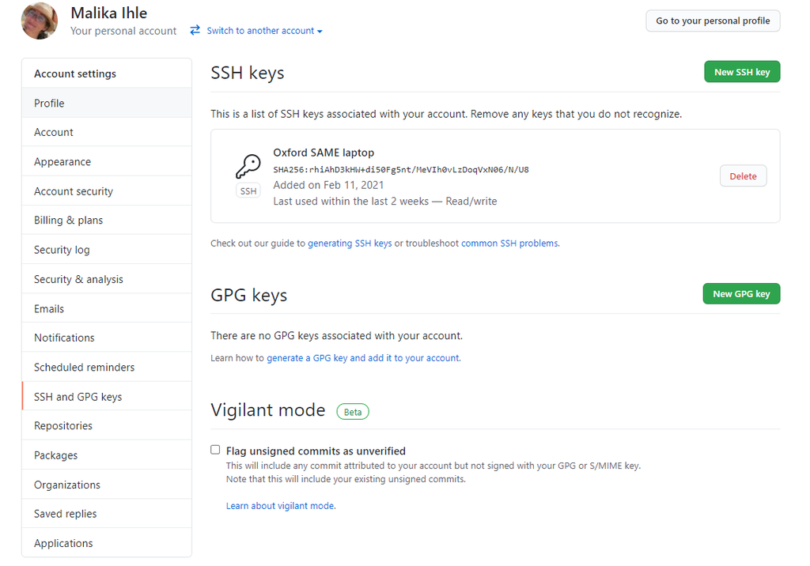

## Adding the SSH key to GitHub account

**Step 4**:

## Adding the SSH key to GitHub account

**Step 4**: continued

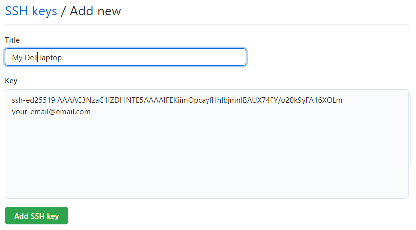

## Adding the SSH key to *ssh-agent*

### (optional step, only necessary if you keep getting asked for your key)

Managing your ssh keys is done via the [ssh-agent](https://smallstep.com/blog/ssh-agent-explained/) software.

**Note**

Depending on your system, the following might not be necessary. On most GNU/Linux distributions and MacOS, your key will be automatically added to the ssh-agent after the first time you enter it.

Only if you keep getting asked for your key each time you want to clone or push to a GitHub repository, you can follow the instructions on the next slides.

Otherwise fast-forward to Testing the GitHub connection

## Adding the SSH key to ssh-agent

**Step 1**: In the command line, start the ssh-agent with this command:

```
Terminal
```

```bash
eval "$(ssh-agent -s)"
```

This should give you this:

```
Agent pid 59566
```

## Adding the SSH key to ssh-agent

**Step 2**: Add your SSH key to the ssh-agent by typing the entirety of this command:

```
Terminal
```

```bash
ssh-add ~/.ssh/id_ed25519
```

## Testing the GitHub connection

**Step 1**: “Ask” GitHub at the command line if our connection is accepted with the following code:

```
Terminal
```

```bash
ssh -T git@github.com
```

## Testing the GitHub connection

**Step 2**: When asked about *fingerprinting*, type *yes*, then press ENTER to receive this output:

```
> Hi USERNAME! You've successfully authenticated, but GitHub does not
> provide shell access.
```

**This is it!**

You have set up a new SSH key pair and successfully let GitHub know your identity to connect your computer to your GitHub account. These steps will only have to be repeated when you change computers. Let the fun begin!

## RECAP: Setting up Git

**What have we done so far?**

- Installed Git ✅
- Configured Git ✅
- Secured a connection between PC and GitHub via SSH key pair ✅
- Added SSH key pair to GitHub account ✅
- Tested the connection between your machine and GitHub ✅

**Ready!**

Your Git and GitHub setup is now secure and ready to use!

## Pre-break survey

Brief check-in: **Your Turn!**

**What is the main purpose of using Git in a project?**

1. To edit code directly on GitHub
2. To automatically test and debug programs
3. To track changes and collaborate on code with version control
4. To back up files to the cloud without version history

**Why do we add an SSH key to our GitHub account when setting up Git?**

1. To store our Git username and password on the computer
2. To allow our computer to connect securely to GitHub without entering a password each time
3. To make Git automatically commit our changes
4. To enable GitHub to edit our files directly on our computer

# Break! 15 minutes

## Post-break survey discussion

What do we see in the results?

## RStudio Project: What is it?

**Local folder** used to organize your work within a self-contained R storage.

- Contains all files related to project: R scripts, source files, location of the R working directory, RStudio workspace …
- Includes shortcut to open the project directly in RStudio

## Creating an RStudio Project

**Step 1**: Create a new project in RStudio as follows: `File`> `New Project` > `New Directory`

[figure not shown]

## Creating an RStudio Project

**Step 2**: In the New Project Wizard screen, click on `New project`:

[figure not shown]

## Creating an RStudio Project

**Step 3**: Give your project a name (e.g.’my_first_test_repo’) and ensure that `Create a git repository` is ticked. Next, click on `Create Project`.

[figure not shown]

**Note**

RStudio will create a new folder containing an empty project and set it as the new R working directory.

## Creating an RStudio Project: Important files

Two files are created in the otherwise empty project:

- **.gitignore**: Specifies files that should be ignored by the version control system (e.g. sensible data files that should not be made public, or documentation that you don’t need version controlled).
- **my_first_test_repo.Rproj**: Configuration information for the RStudio project.

[figure not shown]

## Setting up a small practice project

We will now generate a small project to practice version control on.

**Step 1**: Download dataset to practice analyses on.

## Setting up a small practice project

**Step 2**: Create a new R script `File` > `New File` > `R script` and save it as *myscript.R*. Then add the code below to your R script.

```
myscript.R
```

```r
mydata = read.csv("example_data.csv")
plot(mydata$xdata,mydata$ydata)
```

## Setting up a small practice project

**Step 3**: Run the code and check your directory. It should now contain four files:

[figure not shown]

## Getting your project under version control: Key concepts

Before we do the first action, one orientation point:

- The **Git pane** in RStudio is your control center for version control
- It shows which files changed and what Git knows about them
- This is where you *stage*, *commit*, review *history*, and *sync* with GitHub (all actions will be explained in the following slides)

## Getting your project under version control

**Step 1**: Find the git version control pane in the top right corner of RStudio in the `Git` tab.

[figure not shown]

## Getting your project under version control: Key concepts

Before we click anything, two terms matter:

- **Untracked** = a file exists, but Git is not yet tracking its versions
- **Staged** = changes are selected and prepared for the next commit
- Think of staging as choosing what goes into your next snapshot

## Getting your project under version control

**Step 2**: Hover the mouse pointer over the yellow `?` marks in the Git tab, you’ll see a tooltip telling us that the file is **untracked**. This means that Git is not tracking versions of this file yet. Tick `staged` for each file.

[figure not shown]

## Getting your project under version control: Key concepts

Now the next key idea:

- A **commit** is a saved snapshot in your project history
- It records the staged changes at one meaningful point in time
- Commits let you review what changed and return to earlier states if needed

## Getting your project under version control

**Step 3**: Our staged files are now ready for the first **commit**. Click on the `commit button`.

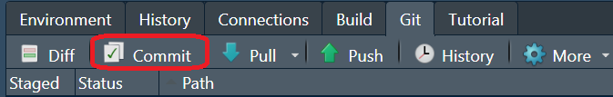

## Getting your project under version control: Key concepts

Every commit needs a message:

- A **commit message** explains what changed (and ideally why)
- Good messages are short, specific, and useful for your future self. They start with a verb in imperative mode, such as: Add, Fix, Improve
- Example: *Add first analysis script and dataset import*

## Getting your project under version control

**Step 4**: Specify a **commit message**, which is a brief description of the changes you made. For now, we will add the commit message *First commit*. Then click on `Commit`.

[figure not shown]

## Getting your project under version control

**Step 5**: Check the message from git. If no errors appear, everything is fine. Click on close - finished!

[figure not shown]

## Making changes

Now we want to make some actual changes to practise using Git and to show how Git handles modifications of files.

**Step 1**: Add the following code to your existing R script:

```
myscript.R
```

```r
# some guesses for the parameters.
p1 = 1
p2 = 0.2

# do the fit
fit = nls(ydata ~ p1*cos(p2*xdata) + p2*sin(p1*xdata), data = mydata, start = list(p1=p1,p2=p2))

#Plot the fitted line
new = data.frame(xdata = seq(min(mydata$xdata),max(mydata$xdata),len=200))
lines(new$xdata,predict(fit,newdata=new))
```

## Making changes

**Step 2**: Change the command that plots our data in this file.

Change the line

```
myscript.R
```

```r
plot(mydata$xdata,mydata$ydata)
```

to

```
myscript.R
```

```r
plot(mydata$xdata,mydata$ydata,col='red')
```

and run this code.

## Making changes: Optional Exercise

**Step 3** (optional): Create another R file with `File` > `New File` > `R script`. Save as *simulation_script.R*. Then add and run the code below in the new R script:

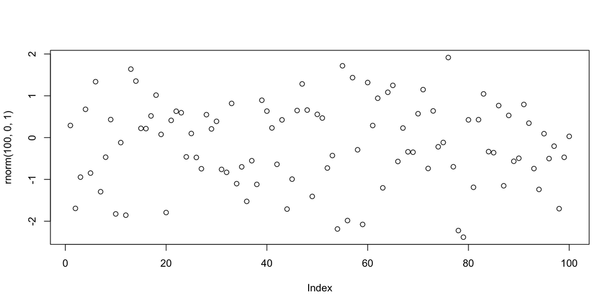

```r
#Simulate some data
plot(rnorm(100,0,1))
```

## Committing changes

Click on the `git` tab in the top right corner. Two files appeared, the script we modified and the new script.

**Step 1**: Click on the `staged` box to stage changes for the *first* script.

[figure not shown]

## Committing changes

**Step 2**: Click on `Diff` for a reminder summary of what changed. Then add a commit message and click `commit`.

[figure not shown]

**Important**

Remember that Git track *differences* between two files. Lines that have been added are green. Lines that have been removed are red.

## Practical exercise 1

- If you have not already done so, create a second R script and save it in your RStudio project folder.
- Stage the second script and write a new commit message.
- In the git tab, press the `History` button to review the change and commit history of your files.

**Note**

By default, the history search feature will show all files added, changed, or deleted for each commit. This can be extremely useful for finding bugs or looking back to how your project looked a few months ago. However, it is often more practical to review the changes made to a single file over time; this enables, for example, clear tracking of the evolution of data cleaning and analysis steps in your project.

## Connecting the local repository to GitHub

The project is now under version control. Time to create a **new GitHub repository** and **upload** to GitHub!

**Step 1**: Log into GitHub and go to your profile page. On the `repositories` tab, click `New`.

[figure not shown]

## Connecting the local repository to GitHub

**Step 2**: Give the repository a name and click `Create Repository`.

[figure not shown]

## Connecting the local repository to GitHub

**Step 3**: Configure the repository in the `Quick Setup` screen. Select the `SSH` tab and make sure the url shown in the blue box should start with git@github.com.

## Connecting the local repository to GitHub

**Step 4**: Copy the commands from the `or push an existing repository from the command line` to your clipboard with the GitHub copy button.

[figure not shown]

## Connecting the local repository to GitHub

**Step 5**: Go to RStudio, navigate to the `git` tab and Click on `More` > `New Terminal`.

[figure not shown]

## Connecting the local repository to GitHub

**Step 6**: Paste the git commands from your clipboard into the terminal and press enter to execute them. Insert your SSH passphrase if prompted or type

```
yes
```

when a sentence about continuing to connect appears in the terminal.

[figure not shown]

## Connecting the local repository to GitHub

**Step 7**: Check that your local repository with your RStudio Project appears on your GitHub profile (please refresh the page once).

**Note**

You only need to upload your local repository **once** to GitHub. In the subsequent section, we explain how to sync (or **push**) your local changes in your RStudio project with the remote repository you just created on GitHub.

## Making changes: Adding a README to your RStudio Project

Imagine that as a follow-up step, we want to add a README file to the RStudio project folder.

**Note**

A README file is a short document that explains what your R project is about and can be viewed as a sort of *Welcome Guide*. It usually includes things like:

- What the project does and who made it
- What files or data are included
- How to use or run the code
- Any special setup or packages needed

## Adding a README to your RStudio Project

**Step 1**: In RStudio, click on `File` > `New File` > `Text File`. Add the following text to the file and save it as **README.md**:

```
README.md
```

```markdown
# My Example Repo

This repo is used to demonstrate GitHub to users of R and R Studio.
```

## Adding a README to your RStudio Project

**Step 2**: In the **git** tab, you should see the new **Readme.md** file (and only that one!). Stage the file and press **commit**.

[figure not shown]

## Adding a README to your RStudio Project

**Step 3**: Add a new commit message and press `Commit` in the bottom right corner.

[figure not shown]

## Adding a README to your RStudio Project

**Step 4**: **Push** the changes to upload to GitHub by pressing the button in the top right corner with the green arrow pointing upwards.

[figure not shown]

## When to stage and commit?

**Important**

**Great question!** The point of version control is to have a **track record** of changes and that you can undo/redo any changes at any time. Therefore, you should stage and commit your changes to version control whenever you finished a clear, logical “unit”, e.g.:

- Added a code chuck or function
- Cleaned your dataset
- Created a new figure
- Updated a paragraph

## RECAP: Version control in RStudio with Git

**What have we done so far?**

- Created an RStudio Project in a local repository ✅
- Created files for the project (code, downloaded data etc.) ✅
- Added version control to our project in the local repository ✅
- Made changes and commit these changes locally ✅
- Connected the local repository with a remote repository ✅
- Synchronised ( = *pushed* ) the local changes to the remote repository ✅

## OVERVIEW: The Git/GitHub workflow

**What do I need to do?**

1. Make changes locally
2. Stage changes locally
3. Commit changes locally with a commit message
4. Push local changes to the remote repository on GitHub

Once you have brought your local repository under version control and connected the remote repository, you will find yourself **repeating the same steps** above **over and over**.

## Activity: One-Minute Paper!

**Why is version control important and useful?** *Take one minute to write down your thoughts on some paper.*

## Why is version control important and useful?

**Some thoughts …**

- **Tracks** every change in your R project and acts as a “time machine” for your code/files
- **Makes mistakes easy to fix** because you can revert to earlier versions anytime
- **Improves reproducibility** by seeing *what* changed, *when*, and *why* it changed
- **Provides a backup via GitHub** for easy sharing and access anywhere

## Reflection

Take 10 minutes now to reflect upon where in your **own current or future research** you could use Git. Write then the steps you will need to implement what you have learned here in that project and which barriers you may face” (e.g., technical, project partners/supervisors, etc.)

## Assignment: Practising the workflow

- In a new local folder, create a new RStudio Project named **git_practice**.
- Download the practise_data.csv file and save it in your project folder

This is a dataset containing the number of athletes that participated in the Summer Olympics over the years.

**Tip**

When creating the new RStudio project, make sure to check `Create a git repository`.

## Assignment: Practising the workflow

(cont.)

- Create a new R script and write code to read in data, inspect the data and plot the number of athletes over time
- Stage and commit changes
- Create a new repository on GitHub and connect it with your new local repository
- Push your changes to GitHub

**Tip**

For the plot, use geom_line() to plot the number of athletes at the Summer Olympics over the years.

## Take-home message

**What are you taking away from today?**

**Keep practising!**

It is all about practise until you develop a routine.

## To conclude: Survey time!

**Which of the following concepts or skills do you *now* feel more confident about in relation to version control? (Select all that apply)**

1. Git
2. GitHub
3. Repositories
4. RStudio Project
5. I am (still) not sure about any of these concepts.

**On a scale of 1 to 5, how comfortable are you with using Git for version control? (1 = Not comfortable at all, 5 = Very comfortable)**

1. 1
2. 2
3. 3
4. 4
5. 5

## Discussion of survey results

What do we see in the results and how do they compare to the previous ratings?

## Always remember …

[figure not shown]

## Help and support

If you get stuck, there is plently of help available:

- [Using Git with RStudio](https://jennybc.github.io/2014-05-12-ubc/ubc-r/session03_git.html) for an introductory overview
- [Git Guides on staging and committing](https://github.com/git-guides/git-commit) for an overview of the workflow
- [Git and GitHub learning resources](https://docs.github.com/en/get-started/start-your-journey/git-and-github-learning-resources) for free interactive courses built in GitHub
- [Git Cheatsheet](https://education.github.com/git-cheat-sheet-education.pdf) featuring tips on installation, setup, staging, committing and pushing
- [The LMU OSC RStudio/Git tutorial](https://lmu-osc.github.io/Introduction-RStudio-Git-GitHub/updates.html) for similar exercises and advanced materials

# Thanks!

Ready for the next session? 😊

## Troubleshooting

Some general pointers on where learners could run into issues:

- **Mistyping the Git commands**: Correct spelling (including spaces) matters, else Git will not recognize the command

## Licence

This work was originally created by [Mike Croucher](https://github.com/mikecroucher) under a CC-BY-SA 4.0 [Creative Commons Attribution 4.0 International License](https://creativecommons.org/licenses/by-sa/4.0/deed.en). It was subsequently adapted by [Malika Ihle](https://www.osc.uni-muenchen.de/about_us/coordinator/index.html) during her time at Reproducible Research Oxford. This current work by Sarah von Grebmer zu Wolfsthurn, Peter Edelsbrunner and Malika Ihle is licensed under a CC-BY-SA 4.0 [Creative Commons Attribution 4.0 International SA License](https://creativecommons.org/licenses/by-sa/4.0/deed.en). It permits unrestricted re-use, distribution, and reproduction in any medium, provided the original work is properly cited. If you remix, transform, or build upon the material, you must distribute your contributions under the same license as the original.

## Contribution statement

**Creator**: Von Grebmer zu Wolfsthurn, Sarah (0000-0002-6413-3895)

**Reviewer**: Schönbrodt, Felix (0000-0002-8282-3910)

**Consultant**: Edelsbrunner, Peter (0000-0001-9102-1090)